# Индивидуальный проект 2 этап

Архитектура компьютеров и операционные системы

Венис Дмитрий

1032253513@rudn.ru

Российский университет дружбы народов

2026-03-20

# Информация

## Докладчик

- Венис Дмитрий
- студент НКАбд-01-25
- Российский университет дружбы народов им. П. Лумумбы
- 1032253513@rudn.ru
- https://github.com/VenisDmitry

# Вводная часть

## Актуальность

В ходе выполнения 2 этапа индивидуального проекта мы разместили информацию о себе и 2 поста,что хорошо скажется на виде самого сайта научного работника и придаст сайту оригинальность

## Объект и предмет исследования

Продолжить работу с сайтом, редактировать его в соответствии с требованиями, добавить данные о себе на сайт.

## Цели и задачи

Продолжить работу с сайтом, редактировать его в соответствии с требованиями, добавить данные о себе на сайт.

# Задание

1. Разместить фотографию владельца сайта.
2. Разместить краткое описание владельца сайта (Biography).
3. Добавить информацию об интересах (Interests).
4. Добавить информацию об образовании (Education).
5. Сделать пост по прошедшей неделе.
6. Добавить пост на тему по выбору: Управление версиями. Git. Непрерывная интеграция и непрерывное развертывание (CI/CD).

# Выполнение индивидуального проекта

Размещаю свою фотографию, информацию об интересах,информацию об образованию (рис. @fig:001)

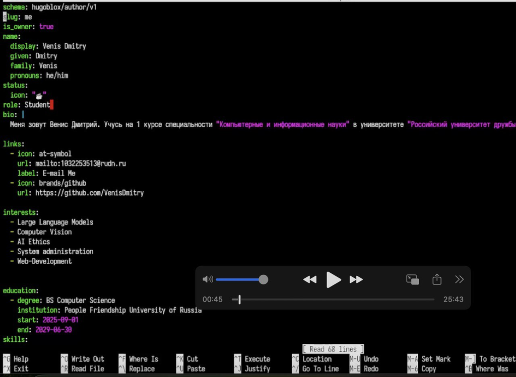

Заполняю информацию

Делаю пост о прошедшей неделе (рис. @fig:002)

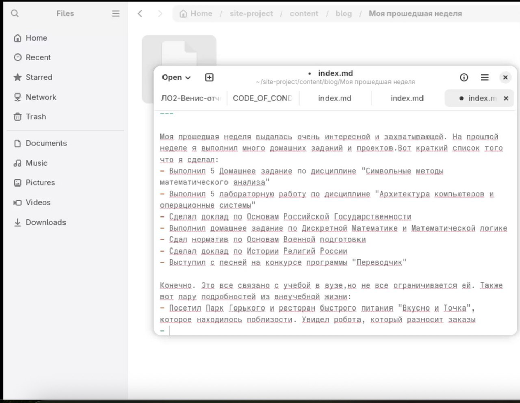

Пост о предыдущей неделе

Добавляю пост на тему:“Управление версиями. Git” (рис. @fig:003)

[figure not shown]

Пост о Git

Проверка изменений на сайте. (рис. @fig:004)

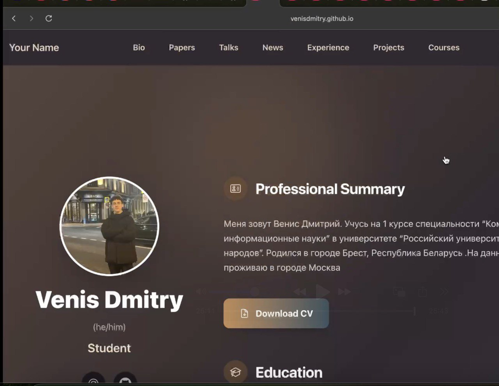

Проверка изменений на сайте

# Выводы

Мы продолжили работу с сайтом, редактировали его в соответствии с требованиями, добавили данные о себе на сайт.

# Список литературы